# Association Rules (Market Basket Analysis)

# Examine Data

To illustrate the process of market basket analysis, let us begin with a simple dataset consisting of a set of nine transactions. Each row represents items purchased on a single visit to a supermarket. Note that specific items as well as number of items vary across visits.

```r
cat(paste(readLines('transactions.csv'),'\n',collapse=''))
```

```
## beer,diapers,bread,
## diapers,eggs,,
## diapers,beer,,
## beer,diapers,eggs,
## beer,diapers,,
## diapers,milk,,
## milk,bread,,
## diapers,beer,milk,bread
## beer,diapers,milk,
```

# Read Data

### Load libraries

```r
library(arules); library(arulesViz)
```

Traditional ways of importing data will result in an incomplete matrix. The read.transactions() function is specifically designed to yield an analysis usable complete matrix.

```r
items = read.transactions('transactions.csv',format='basket',sep=',')
as(items,'matrix')
```

```
##        beer bread diapers  eggs  milk
##  [1,]  TRUE  TRUE    TRUE FALSE FALSE
##  [2,] FALSE FALSE    TRUE  TRUE FALSE
##  [3,]  TRUE FALSE    TRUE FALSE FALSE
##  [4,]  TRUE FALSE    TRUE  TRUE FALSE
##  [5,]  TRUE FALSE    TRUE FALSE FALSE
##  [6,] FALSE FALSE    TRUE FALSE  TRUE
##  [7,] FALSE  TRUE   FALSE FALSE  TRUE
##  [8,]  TRUE  TRUE    TRUE FALSE  TRUE
##  [9,]  TRUE FALSE    TRUE FALSE  TRUE
```

read.transactions() yields an arules object where transactions are organized along rows and items along columns. Here are the transactions and items

```r
items
```

```
## transactions in sparse format with
##  9 transactions (rows) and
##  5 items (columns)
```

Number of transactions or market baskets

```r
dim(items)[1]
```

```
## [1] 9
```

Total number of items

```r
dim(items)[2]
```

```
## [1] 5
```

A summary of all transactions

```r
summary(items)
```

```
## transactions as itemMatrix in sparse format with
##  9 rows (elements/itemsets/transactions) and
##  5 columns (items) and a density of 0.5111111
##
## most frequent items:
## diapers    beer    milk   bread    eggs (Other)
##       8       6       4       3       2       0
##
## element (itemset/transaction) length distribution:
## sizes
## 2 3 4
## 5 3 1
##
##    Min. 1st Qu.  Median    Mean 3rd Qu.    Max.
##   2.000   2.000   2.000   2.556   3.000   4.000
##
## includes extended item information - examples:
##    labels
## 1    beer
## 2   bread
## 3 diapers
```

# Explore Data

Examine individual items. Support is set to 0 so we can see all items.

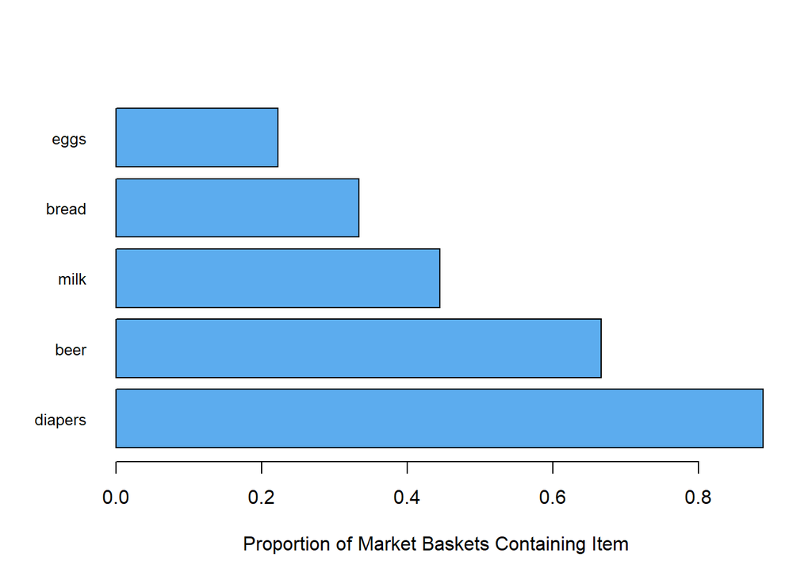

```r
itemFrequencyPlot(items, support = 0.0, cex.names=0.8,
                  type = "relative", horiz = TRUE, col = "steelblue2", las = 1, topN=5,
                  xlab = paste("Proportion of Market Baskets Containing Item"))
```

### Frequency or Counts

Compute the frequency of occurence of various pairs of items. Note measure=‘count’ is the default, code below will generate the same result if measure is not specified

```r
crossTable(items,measure='count',sort=T)
```

```
##         diapers beer milk bread eggs
## diapers       8    6    3     2    2
## beer          6    6    2     2    1
## milk          3    2    4     2    0
## bread         2    2    2     3    0
## eggs          2    1    0     0    2
```

### Support

Prevalence of an item set

```r
crossTable(items,measure='support',sort=T)
```

```
##           diapers      beer      milk     bread      eggs
## diapers 0.8888889 0.6666667 0.3333333 0.2222222 0.2222222
## beer    0.6666667 0.6666667 0.2222222 0.2222222 0.1111111
## milk    0.3333333 0.2222222 0.4444444 0.2222222 0.0000000
## bread   0.2222222 0.2222222 0.2222222 0.3333333 0.0000000
## eggs    0.2222222 0.1111111 0.0000000 0.0000000 0.2222222
```

### Lift

Strength of association. Lift of 1 indicates independence, i.e., no association

```r
crossTable(items,measure='lift',sort=T)
```

```
##         diapers  beer    milk bread  eggs
## diapers      NA 1.125 0.84375  0.75 1.125
## beer    1.12500    NA 0.75000  1.00 0.750
## milk    0.84375 0.750      NA  1.50 0.000
## bread   0.75000 1.000 1.50000    NA 0.000
## eggs    1.12500 0.750 0.00000  0.00    NA
```

# Analysis

### Association Rules

Even a small number of products can generate a pretty large number of rules

```r
rules_all = apriori(items,parameter=list(support=0,confidence=0))
```

```
## Apriori
##
## Parameter specification:
##  confidence minval smax arem  aval originalSupport maxtime support minlen
##           0    0.1    1 none FALSE            TRUE       5       0      1
##  maxlen target  ext
##      10  rules TRUE
##
## Algorithmic control:
##  filter tree heap memopt load sort verbose
##     0.1 TRUE TRUE  FALSE TRUE    2    TRUE
##
## Absolute minimum support count: 0
##
## set item appearances ...[0 item(s)] done [0.00s].
## set transactions ...[5 item(s), 9 transaction(s)] done [0.00s].
## sorting and recoding items ... [5 item(s)] done [0.00s].
## creating transaction tree ... done [0.00s].
## checking subsets of size 1 2 3 4 done [0.00s].
## writing ... [75 rule(s)] done [0.00s].
## creating S4 object  ... done [0.00s].
```

```r
summary(rules_all)
```

```
## set of 75 rules
##
## rule length distribution (lhs + rhs):sizes
##  1  2  3  4
##  5 20 30 20
##
##    Min. 1st Qu.  Median    Mean 3rd Qu.    Max.
##   1.000   2.000   3.000   2.867   4.000   4.000
##
## summary of quality measures:
##     support         confidence         coverage           lift
##  Min.   :0.0000   Min.   :0.00000   Min.   :0.0000   Min.   :0.0000
##  1st Qu.:0.0000   1st Qu.:0.08333   1st Qu.:0.0000   1st Qu.:0.2812
##  Median :0.1111   Median :0.50000   Median :0.2222   Median :1.0000
##  Mean   :0.1304   Mean   :0.52130   Mean   :0.3472   Mean   :0.9333
##  3rd Qu.:0.2222   3rd Qu.:1.00000   3rd Qu.:0.6667   3rd Qu.:1.1250
##  Max.   :0.8889   Max.   :1.00000   Max.   :1.0000   Max.   :3.0000
##                                     NA's   :19
##      count
##  Min.   :0.000
##  1st Qu.:0.000
##  Median :1.000
##  Mean   :1.173
##  3rd Qu.:2.000
##  Max.   :8.000
##
##
## mining info:
##   data ntransactions support confidence
##  items             9       0          0
##                                                                  call
##  apriori(data = items, parameter = list(support = 0, confidence = 0))
```

```r
x = inspect(rules_all)
```

```
##      lhs                       rhs       support   confidence coverage  lift
## [1]  {}                     => {eggs}    0.2222222 0.2222222  1.0000000 1.00000
## [2]  {}                     => {bread}   0.3333333 0.3333333  1.0000000 1.00000
## [3]  {}                     => {milk}    0.4444444 0.4444444  1.0000000 1.00000
## [4]  {}                     => {beer}    0.6666667 0.6666667  1.0000000 1.00000
## [5]  {}                     => {diapers} 0.8888889 0.8888889  1.0000000 1.00000
## [6]  {eggs}                 => {bread}   0.0000000 0.0000000        NaN 0.00000
## [7]  {bread}                => {eggs}    0.0000000 0.0000000        NaN 0.00000
## [8]  {eggs}                 => {milk}    0.0000000 0.0000000        NaN 0.00000
## [9]  {milk}                 => {eggs}    0.0000000 0.0000000        NaN 0.00000
## [10] {eggs}                 => {beer}    0.1111111 0.5000000  0.2222222 0.75000
## [11] {beer}                 => {eggs}    0.1111111 0.1666667  0.6666667 0.75000
## [12] {eggs}                 => {diapers} 0.2222222 1.0000000  0.2222222 1.12500
## [13] {diapers}              => {eggs}    0.2222222 0.2500000  0.8888889 1.12500
## [14] {bread}                => {milk}    0.2222222 0.6666667  0.3333333 1.50000
```

[output cut: 137 more lines]

The object resulting from inspect() is a dataframe, so it can be subset and sorted using commonly used approaches.

```r
x = x[x$count!=0,]
x[order(x$lift,x$support, decreasing = T),]
```

|  | lhs |  | rhs | support | confidence | coverage | lift | count |
| --- | --- | --- | --- | --- | --- | --- | --- | --- |
| [14] | {bread} | => | {milk} | 0.2222222 | 0.6666667 | 0.3333333 | 1.50000 | 2 |
| [15] | {milk} | => | {bread} | 0.2222222 | 0.5000000 | 0.4444444 | 1.50000 | 2 |
| [51] | {bread, diapers} | => | {beer} | 0.2222222 | 1.0000000 | 0.2222222 | 1.50000 | 2 |
| [46] | {beer, milk} | => | {bread} | 0.1111111 | 0.5000000 | 0.2222222 | 1.50000 | 1 |
| [73] | {bread, diapers, milk} | => | {beer} | 0.1111111 | 1.0000000 | 0.1111111 | 1.50000 | 1 |
| [75] | {beer, diapers, milk} | => | {bread} | 0.1111111 | 0.5000000 | 0.2222222 | 1.50000 | 1 |
| [24] | {beer} | => | {diapers} | 0.6666667 | 1.0000000 | 0.6666667 | 1.12500 | 6 |
| [25] | {diapers} | => | {beer} | 0.6666667 | 0.7500000 | 0.8888889 | 1.12500 | 6 |
| [12] | {eggs} | => | {diapers} | 0.2222222 | 1.0000000 | 0.2222222 | 1.12500 | 2 |
| [13] | {diapers} | => | {eggs} | 0.2222222 | 0.2500000 | 0.8888889 | 1.12500 | 2 |

[output cut: 30 more lines]

### Reduce Rules

It is prudent to examine only strong rules. Here, we only retain rules with support>=0.001 and confidence>=0.05

```r
rules1 = apriori(items,parameter = list(support = 0.001, confidence = 0.05))
```

```
## Apriori
##
## Parameter specification:
##  confidence minval smax arem  aval originalSupport maxtime support minlen
##        0.05    0.1    1 none FALSE            TRUE       5   0.001      1
##  maxlen target  ext
##      10  rules TRUE
##
## Algorithmic control:
##  filter tree heap memopt load sort verbose
##     0.1 TRUE TRUE  FALSE TRUE    2    TRUE
##
## Absolute minimum support count: 0
##
## set item appearances ...[0 item(s)] done [0.00s].
## set transactions ...[5 item(s), 9 transaction(s)] done [0.00s].
## sorting and recoding items ... [5 item(s)] done [0.00s].
## creating transaction tree ... done [0.00s].
## checking subsets of size 1 2 3 4 done [0.00s].
## writing ... [40 rule(s)] done [0.00s].
## creating S4 object  ... done [0.00s].
```

```r
summary(rules1)   # too many rules?
```

```
## set of 40 rules
##
## rule length distribution (lhs + rhs):sizes
##  1  2  3  4
##  5 16 15  4
##
##    Min. 1st Qu.  Median    Mean 3rd Qu.    Max.
##    1.00    2.00    2.00    2.45    3.00    4.00
##
## summary of quality measures:
##     support         confidence        coverage           lift
##  Min.   :0.1111   Min.   :0.1667   Min.   :0.1111   Min.   :0.5625
##  1st Qu.:0.1111   1st Qu.:0.3333   1st Qu.:0.2222   1st Qu.:0.7500
##  Median :0.2222   Median :0.5000   Median :0.3333   Median :1.0000
##  Mean   :0.2444   Mean   :0.5774   Mean   :0.4861   Mean   :1.0281
##  3rd Qu.:0.2222   3rd Qu.:0.7500   3rd Qu.:0.6667   3rd Qu.:1.1250
##  Max.   :0.8889   Max.   :1.0000   Max.   :1.0000   Max.   :1.5000
##      count
##  Min.   :1.0
##  1st Qu.:1.0
##  Median :2.0
##  Mean   :2.2
##  3rd Qu.:2.0
##  Max.   :8.0
##
## mining info:
##   data ntransactions support confidence
##  items             9   0.001       0.05
##                                                                         call
##  apriori(data = items, parameter = list(support = 0.001, confidence = 0.05))
```

```r
inspect(rules1)
```

```
##      lhs                       rhs       support   confidence coverage  lift
## [1]  {}                     => {eggs}    0.2222222 0.2222222  1.0000000 1.00000
## [2]  {}                     => {bread}   0.3333333 0.3333333  1.0000000 1.00000
## [3]  {}                     => {milk}    0.4444444 0.4444444  1.0000000 1.00000
## [4]  {}                     => {beer}    0.6666667 0.6666667  1.0000000 1.00000
## [5]  {}                     => {diapers} 0.8888889 0.8888889  1.0000000 1.00000
## [6]  {eggs}                 => {beer}    0.1111111 0.5000000  0.2222222 0.75000
## [7]  {beer}                 => {eggs}    0.1111111 0.1666667  0.6666667 0.75000
## [8]  {eggs}                 => {diapers} 0.2222222 1.0000000  0.2222222 1.12500
## [9]  {diapers}              => {eggs}    0.2222222 0.2500000  0.8888889 1.12500
## [10] {bread}                => {milk}    0.2222222 0.6666667  0.3333333 1.50000
## [11] {milk}                 => {bread}   0.2222222 0.5000000  0.4444444 1.50000
## [12] {bread}                => {beer}    0.2222222 0.6666667  0.3333333 1.00000
## [13] {beer}                 => {bread}   0.2222222 0.3333333  0.6666667 1.00000
## [14] {bread}                => {diapers} 0.2222222 0.6666667  0.3333333 0.75000
```

[output cut: 67 more lines]

```r
quality(rules1) # hide rule details
```

|  | support | confidence | coverage | lift | count |
| --- | --- | --- | --- | --- | --- |
| 1 | 0.2222222 | 0.2222222 | 1.0000000 | 1.00000 | 2 |
| 2 | 0.3333333 | 0.3333333 | 1.0000000 | 1.00000 | 3 |
| 3 | 0.4444444 | 0.4444444 | 1.0000000 | 1.00000 | 4 |
| 4 | 0.6666667 | 0.6666667 | 1.0000000 | 1.00000 | 6 |
| 5 | 0.8888889 | 0.8888889 | 1.0000000 | 1.00000 | 8 |
| 6 | 0.1111111 | 0.5000000 | 0.2222222 | 0.75000 | 1 |
| 7 | 0.1111111 | 0.1666667 | 0.6666667 | 0.75000 | 1 |
| 8 | 0.2222222 | 1.0000000 | 0.2222222 | 1.12500 | 2 |
| 9 | 0.2222222 | 0.2500000 | 0.8888889 | 1.12500 | 2 |
| 10 | 0.2222222 | 0.6666667 | 0.3333333 | 1.50000 | 2 |

[output cut: 30 more lines]

### Reduce rules further

Only keeping rules with a support>=0.2 and confidence>=0.2

```r
rules2 = apriori(items,parameter = list(support = 0.2, confidence = 0.2))
```

```
## Apriori
##
## Parameter specification:
##  confidence minval smax arem  aval originalSupport maxtime support minlen
##         0.2    0.1    1 none FALSE            TRUE       5     0.2      1
##  maxlen target  ext
##      10  rules TRUE
##
## Algorithmic control:
##  filter tree heap memopt load sort verbose
##     0.1 TRUE TRUE  FALSE TRUE    2    TRUE
##
## Absolute minimum support count: 1
##
## set item appearances ...[0 item(s)] done [0.00s].
## set transactions ...[5 item(s), 9 transaction(s)] done [0.00s].
## sorting and recoding items ... [5 item(s)] done [0.00s].
## creating transaction tree ... done [0.00s].
## checking subsets of size 1 2 3 done [0.00s].
## writing ... [25 rule(s)] done [0.00s].
## creating S4 object  ... done [0.00s].
```

```r
x = inspect(rules2)
```

```
##      lhs                 rhs       support   confidence coverage  lift    count
## [1]  {}               => {eggs}    0.2222222 0.2222222  1.0000000 1.00000 2
## [2]  {}               => {bread}   0.3333333 0.3333333  1.0000000 1.00000 3
## [3]  {}               => {milk}    0.4444444 0.4444444  1.0000000 1.00000 4
## [4]  {}               => {beer}    0.6666667 0.6666667  1.0000000 1.00000 6
## [5]  {}               => {diapers} 0.8888889 0.8888889  1.0000000 1.00000 8
## [6]  {eggs}           => {diapers} 0.2222222 1.0000000  0.2222222 1.12500 2
## [7]  {diapers}        => {eggs}    0.2222222 0.2500000  0.8888889 1.12500 2
## [8]  {bread}          => {milk}    0.2222222 0.6666667  0.3333333 1.50000 2
## [9]  {milk}           => {bread}   0.2222222 0.5000000  0.4444444 1.50000 2
## [10] {bread}          => {beer}    0.2222222 0.6666667  0.3333333 1.00000 2
## [11] {beer}           => {bread}   0.2222222 0.3333333  0.6666667 1.00000 2
## [12] {bread}          => {diapers} 0.2222222 0.6666667  0.3333333 0.75000 2
## [13] {diapers}        => {bread}   0.2222222 0.2500000  0.8888889 0.75000 2
## [14] {milk}           => {beer}    0.2222222 0.5000000  0.4444444 0.75000 2
## [15] {beer}           => {milk}    0.2222222 0.3333333  0.6666667 0.75000 2
## [16] {milk}           => {diapers} 0.3333333 0.7500000  0.4444444 0.84375 3
## [17] {diapers}        => {milk}    0.3333333 0.3750000  0.8888889 0.84375 3
## [18] {beer}           => {diapers} 0.6666667 1.0000000  0.6666667 1.12500 6
## [19] {diapers}        => {beer}    0.6666667 0.7500000  0.8888889 1.12500 6
## [20] {beer, bread}    => {diapers} 0.2222222 1.0000000  0.2222222 1.12500 2
## [21] {bread, diapers} => {beer}    0.2222222 1.0000000  0.2222222 1.50000 2
## [22] {beer, diapers}  => {bread}   0.2222222 0.3333333  0.6666667 1.00000 2
## [23] {beer, milk}     => {diapers} 0.2222222 1.0000000  0.2222222 1.12500 2
## [24] {diapers, milk}  => {beer}    0.2222222 0.6666667  0.3333333 1.00000 2
## [25] {beer, diapers}  => {milk}    0.2222222 0.3333333  0.6666667 0.75000 2
```

```r
x[order(x$lift,x$support, decreasing = T),]
```

|  | lhs |  | rhs | support | confidence | coverage | lift | count |
| --- | --- | --- | --- | --- | --- | --- | --- | --- |
| [8] | {bread} | => | {milk} | 0.2222222 | 0.6666667 | 0.3333333 | 1.50000 | 2 |
| [9] | {milk} | => | {bread} | 0.2222222 | 0.5000000 | 0.4444444 | 1.50000 | 2 |
| [21] | {bread, diapers} | => | {beer} | 0.2222222 | 1.0000000 | 0.2222222 | 1.50000 | 2 |
| [18] | {beer} | => | {diapers} | 0.6666667 | 1.0000000 | 0.6666667 | 1.12500 | 6 |
| [19] | {diapers} | => | {beer} | 0.6666667 | 0.7500000 | 0.8888889 | 1.12500 | 6 |
| [6] | {eggs} | => | {diapers} | 0.2222222 | 1.0000000 | 0.2222222 | 1.12500 | 2 |
| [7] | {diapers} | => | {eggs} | 0.2222222 | 0.2500000 | 0.8888889 | 1.12500 | 2 |
| [20] | {beer, bread} | => | {diapers} | 0.2222222 | 1.0000000 | 0.2222222 | 1.12500 | 2 |
| [23] | {beer, milk} | => | {diapers} | 0.2222222 | 1.0000000 | 0.2222222 | 1.12500 | 2 |
| [5] | {} | => | {diapers} | 0.8888889 | 0.8888889 | 1.0000000 | 1.00000 | 8 |

[output cut: 15 more lines]

### Diapers only

Here we are going to narrow our search to just rules with diapers in LHS. Furthermore, we will subset the rules to only those with a lift greater than 1.

```r
rules_diapers = apriori(items,parameter=list(support=0.001,confidence=0.05),
                        appearance = list(lhs='diapers'))
```

```
## Apriori
##
## Parameter specification:
##  confidence minval smax arem  aval originalSupport maxtime support minlen
##        0.05    0.1    1 none FALSE            TRUE       5   0.001      1
##  maxlen target  ext
##      10  rules TRUE
##
## Algorithmic control:
##  filter tree heap memopt load sort verbose
##     0.1 TRUE TRUE  FALSE TRUE    2    TRUE
##
## Absolute minimum support count: 0
##
## set item appearances ...[1 item(s)] done [0.00s].
## set transactions ...[5 item(s), 9 transaction(s)] done [0.00s].
## sorting and recoding items ... [5 item(s)] done [0.00s].
## creating transaction tree ... done [0.00s].
## checking subsets of size 1 2 done [0.00s].
## writing ... [8 rule(s)] done [0.00s].
## creating S4 object  ... done [0.00s].
```

```r
rules_diapers = subset(rules_diapers, subset= lift>1)
inspect(rules_diapers)
```

```
##     lhs          rhs    support   confidence coverage  lift  count
## [1] {diapers} => {eggs} 0.2222222 0.25       0.8888889 1.125 2
## [2] {diapers} => {beer} 0.6666667 0.75       0.8888889 1.125 6
```

#### Diapers only with dplyr

```r
library(dplyr)

apriori(data = items, parameter = list(support=0,confidence=0),appearance = list(lhs='diapers'))%>%
  inspect()%>%
  janitor::clean_names()%>%
  filter(count>0, support>0)%>%
  arrange(desc(lift),desc(support))
```

```
## Apriori
##
## Parameter specification:
##  confidence minval smax arem  aval originalSupport maxtime support minlen
##           0    0.1    1 none FALSE            TRUE       5       0      1
##  maxlen target  ext
##      10  rules TRUE
##
## Algorithmic control:
##  filter tree heap memopt load sort verbose
##     0.1 TRUE TRUE  FALSE TRUE    2    TRUE
##
## Absolute minimum support count: 0
##
## set item appearances ...[1 item(s)] done [0.00s].
## set transactions ...[5 item(s), 9 transaction(s)] done [0.00s].
## sorting and recoding items ... [5 item(s)] done [0.00s].
## creating transaction tree ... done [0.00s].
## checking subsets of size 1 2 done [0.00s].
## writing ... [8 rule(s)] done [0.00s].
## creating S4 object  ... done [0.00s].
##     lhs          rhs     support   confidence coverage  lift    count
## [1] {}        => {eggs}  0.2222222 0.2222222  1.0000000 1.00000 2
## [2] {}        => {bread} 0.3333333 0.3333333  1.0000000 1.00000 3
## [3] {}        => {milk}  0.4444444 0.4444444  1.0000000 1.00000 4
## [4] {}        => {beer}  0.6666667 0.6666667  1.0000000 1.00000 6
## [5] {diapers} => {eggs}  0.2222222 0.2500000  0.8888889 1.12500 2
## [6] {diapers} => {bread} 0.2222222 0.2500000  0.8888889 0.75000 2
## [7] {diapers} => {milk}  0.3333333 0.3750000  0.8888889 0.84375 3
## [8] {diapers} => {beer}  0.6666667 0.7500000  0.8888889 1.12500 6
```

|  | lhs | x | rhs | support | confidence | coverage | lift | count |
| --- | --- | --- | --- | --- | --- | --- | --- | --- |
| [8] | {diapers} | => | {beer} | 0.6666667 | 0.7500000 | 0.8888889 | 1.12500 | 6 |
| [5] | {diapers} | => | {eggs} | 0.2222222 | 0.2500000 | 0.8888889 | 1.12500 | 2 |
| [4] | {} | => | {beer} | 0.6666667 | 0.6666667 | 1.0000000 | 1.00000 | 6 |
| [3] | {} | => | {milk} | 0.4444444 | 0.4444444 | 1.0000000 | 1.00000 | 4 |
| [2] | {} | => | {bread} | 0.3333333 | 0.3333333 | 1.0000000 | 1.00000 | 3 |
| [1] | {} | => | {eggs} | 0.2222222 | 0.2222222 | 1.0000000 | 1.00000 | 2 |
| [7] | {diapers} | => | {milk} | 0.3333333 | 0.3750000 | 0.8888889 | 0.84375 | 3 |
| [6] | {diapers} | => | {bread} | 0.2222222 | 0.2500000 | 0.8888889 | 0.75000 | 2 |

### Rules with only two items

```r
rules_2items = apriori(items,parameter=list(support=0.001,confidence=0.05,minlen=2,maxlen=2))
```

```
## Apriori
##
## Parameter specification:
##  confidence minval smax arem  aval originalSupport maxtime support minlen
##        0.05    0.1    1 none FALSE            TRUE       5   0.001      2
##  maxlen target  ext
##       2  rules TRUE
##
## Algorithmic control:
##  filter tree heap memopt load sort verbose
##     0.1 TRUE TRUE  FALSE TRUE    2    TRUE
##
## Absolute minimum support count: 0
##
## set item appearances ...[0 item(s)] done [0.00s].
## set transactions ...[5 item(s), 9 transaction(s)] done [0.00s].
## sorting and recoding items ... [5 item(s)] done [0.00s].
## creating transaction tree ... done [0.00s].
## checking subsets of size 1 2 done [0.00s].
## writing ... [16 rule(s)] done [0.00s].
## creating S4 object  ... done [0.00s].
```

```r
summary(rules_2items)
```

```
## set of 16 rules
##
## rule length distribution (lhs + rhs):sizes
##  2
## 16
##
##    Min. 1st Qu.  Median    Mean 3rd Qu.    Max.
##       2       2       2       2       2       2
##
## summary of quality measures:
##     support         confidence        coverage           lift
##  Min.   :0.1111   Min.   :0.1667   Min.   :0.2222   Min.   :0.7500
##  1st Qu.:0.2222   1st Qu.:0.3333   1st Qu.:0.3333   1st Qu.:0.7500
##  Median :0.2222   Median :0.5000   Median :0.5556   Median :0.9219
##  Mean   :0.2778   Mean   :0.5443   Mean   :0.5625   Mean   :0.9805
##  3rd Qu.:0.2500   3rd Qu.:0.6875   3rd Qu.:0.7222   3rd Qu.:1.1250
##  Max.   :0.6667   Max.   :1.0000   Max.   :0.8889   Max.   :1.5000
##      count
##  Min.   :1.00
##  1st Qu.:2.00
##  Median :2.00
##  Mean   :2.50
##  3rd Qu.:2.25
##  Max.   :6.00
##
## mining info:
##   data ntransactions support confidence
##  items             9   0.001       0.05
##                                                                                                 call
##  apriori(data = items, parameter = list(support = 0.001, confidence = 0.05, minlen = 2, maxlen = 2))
```

```r
inspect(rules_2items)
```

```
##      lhs          rhs       support   confidence coverage  lift    count
## [1]  {eggs}    => {beer}    0.1111111 0.5000000  0.2222222 0.75000 1
## [2]  {beer}    => {eggs}    0.1111111 0.1666667  0.6666667 0.75000 1
## [3]  {eggs}    => {diapers} 0.2222222 1.0000000  0.2222222 1.12500 2
## [4]  {diapers} => {eggs}    0.2222222 0.2500000  0.8888889 1.12500 2
## [5]  {bread}   => {milk}    0.2222222 0.6666667  0.3333333 1.50000 2
## [6]  {milk}    => {bread}   0.2222222 0.5000000  0.4444444 1.50000 2
## [7]  {bread}   => {beer}    0.2222222 0.6666667  0.3333333 1.00000 2
## [8]  {beer}    => {bread}   0.2222222 0.3333333  0.6666667 1.00000 2
## [9]  {bread}   => {diapers} 0.2222222 0.6666667  0.3333333 0.75000 2
## [10] {diapers} => {bread}   0.2222222 0.2500000  0.8888889 0.75000 2
## [11] {milk}    => {beer}    0.2222222 0.5000000  0.4444444 0.75000 2
## [12] {beer}    => {milk}    0.2222222 0.3333333  0.6666667 0.75000 2
## [13] {milk}    => {diapers} 0.3333333 0.7500000  0.4444444 0.84375 3
## [14] {diapers} => {milk}    0.3333333 0.3750000  0.8888889 0.84375 3
## [15] {beer}    => {diapers} 0.6666667 1.0000000  0.6666667 1.12500 6
## [16] {diapers} => {beer}    0.6666667 0.7500000  0.8888889 1.12500 6
```

# Visualize

### Visualize Association Rules

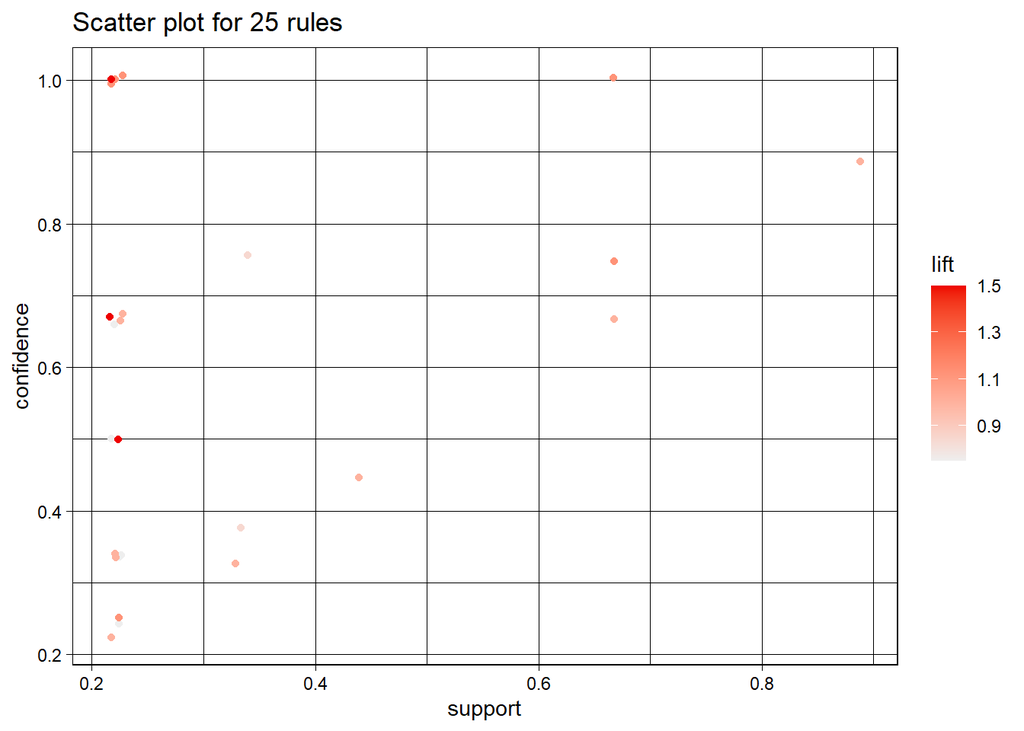

```r
library(RColorBrewer)
plot(rules2) # default method = 'scatterplot', measure=c('support','confidence'), shading='lift'
```

Same plot with the defaults spelt out, a bit of color and jitter. interactive does not work in RMarkdown.

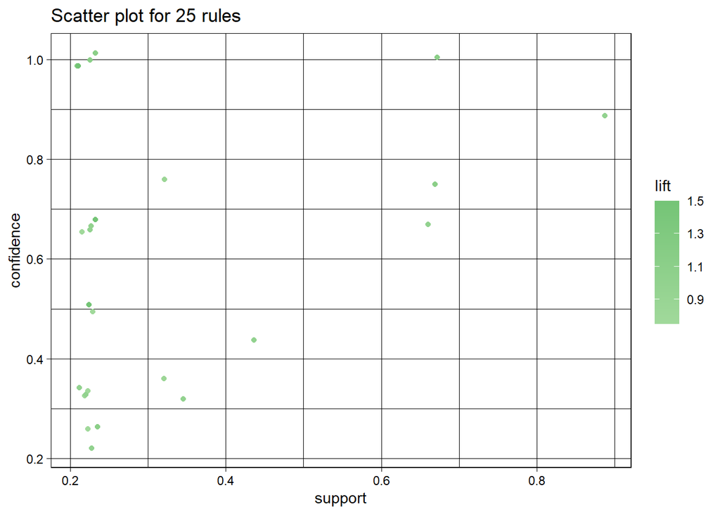

```r
plot(rules2,method='scatterplot',measure=c('support','confidence'),
     control=list(jitter=1, col = rev(brewer.pal(9, "Greens")[4:9])),shading = "lift")
```

Scatterplot with Lift on the y-axis

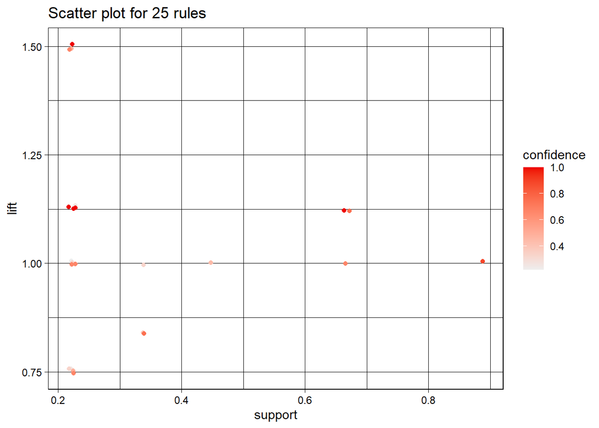

```r
plot(rules2,method='scatterplot',measure=c('support','lift'),shading='confidence')
```

If one is interested in distinguishing between rules by order

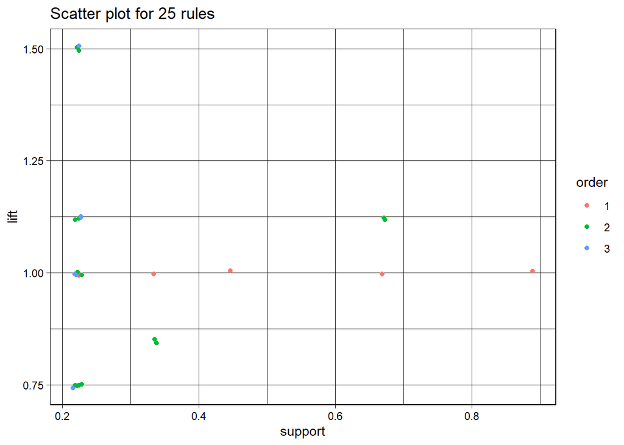

```r
plot(rules2,method='scatterplot',measure=c('support','lift'),shading='order')
```

### Grouped Matrix of Rules

default is measure=‘support’,shading=‘lift’

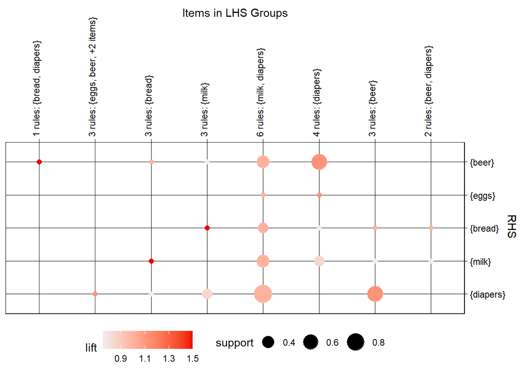

```r
plot(rules2, method="grouped", measure = 'support',shading='lift')
```

### Matrix of charts

Matrix of charts is meaningful only in interactive mode

```
## Itemsets in Antecedent (LHS)
##  [1] "{bread,diapers,milk}" "{beer,diapers,milk}"  "{beer,milk}"
##  [4] "{bread,diapers}"      "{beer,eggs}"          "{beer,bread}"
##  [7] "{beer,bread,milk}"    "{beer,bread,diapers}" "{bread}"
## [10] "{milk}"               "{}"                   "{diapers,milk}"
## [13] "{diapers}"            "{eggs}"               "{beer}"
## [16] "{beer,diapers}"       "{diapers,eggs}"       "{bread,milk}"
## Itemsets in Consequent (RHS)
## [1] "{eggs}"    "{diapers}" "{beer}"    "{milk}"    "{bread}"
```

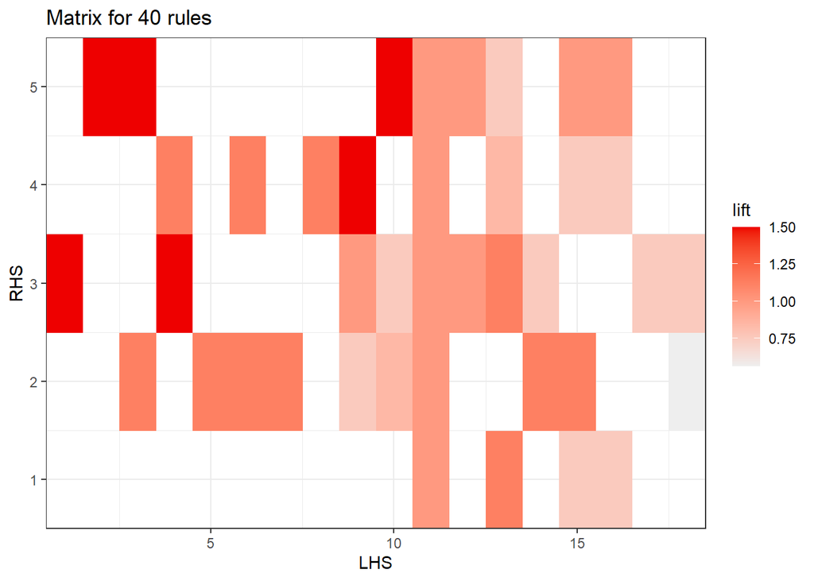

```r
plot(rules_all[quality(rules_all)$support>0,],
     method="matrix", measure="lift", control=list(reorder='measure'))
```

### Matrix 3d

```
## Itemsets in Antecedent (LHS)
##  [1] "{bread,diapers,milk}" "{beer,diapers,milk}"  "{beer,milk}"
##  [4] "{bread,diapers}"      "{beer,eggs}"          "{beer,bread}"
##  [7] "{beer,bread,milk}"    "{beer,bread,diapers}" "{bread}"
## [10] "{milk}"               "{}"                   "{diapers,milk}"
## [13] "{diapers}"            "{eggs}"               "{beer}"
## [16] "{beer,diapers}"       "{diapers,eggs}"       "{bread,milk}"
## Itemsets in Consequent (RHS)
## [1] "{eggs}"    "{diapers}" "{beer}"    "{milk}"    "{bread}"
```

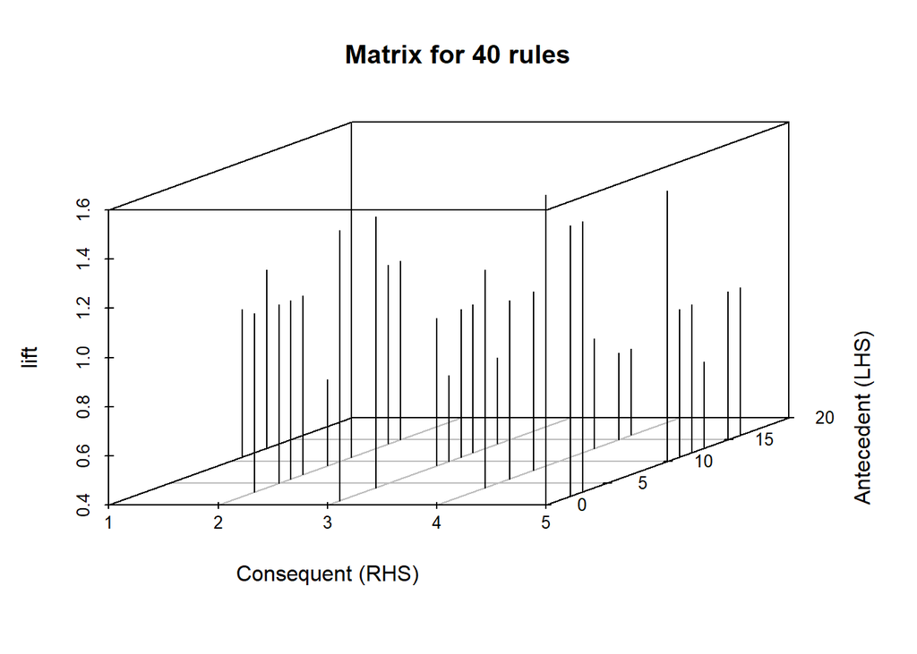

```r
plot(rules_all[quality(rules_all)$support>0,],
     method="matrix", measure="lift", control=list(reorder='measure'), engine='3d')
```

### Network of Rules

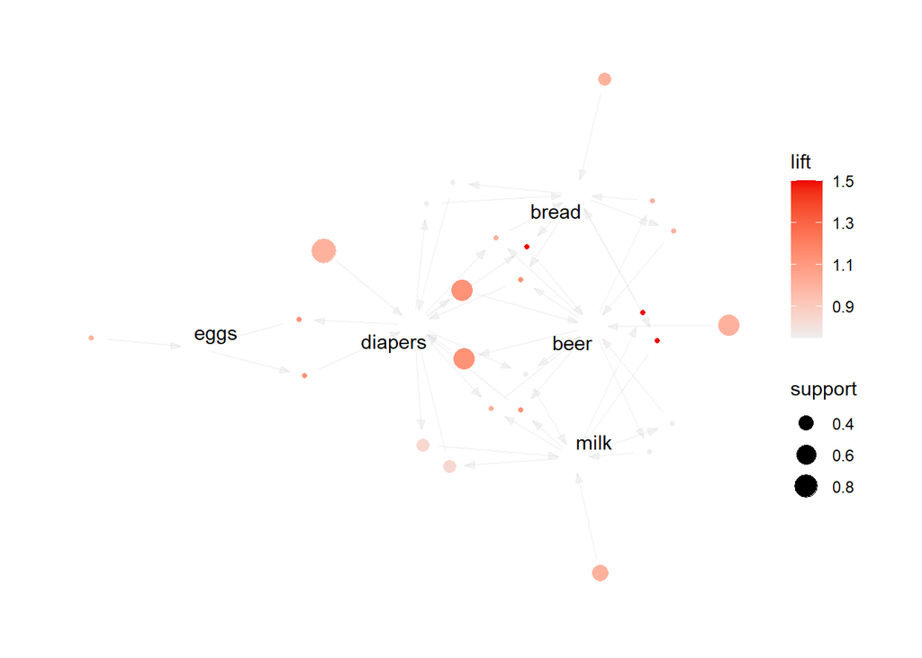

```r
plot(rules2, method="graph", shading = "lift")
```

### Diaper Rules

```r
rules_diapers = apriori(items,parameter=list(support=0.001,confidence=0.05),appearance = list(lhs='diapers'))
```

```
## Apriori
##
## Parameter specification:
##  confidence minval smax arem  aval originalSupport maxtime support minlen
##        0.05    0.1    1 none FALSE            TRUE       5   0.001      1
##  maxlen target  ext
##      10  rules TRUE
##
## Algorithmic control:
##  filter tree heap memopt load sort verbose
##     0.1 TRUE TRUE  FALSE TRUE    2    TRUE
##
## Absolute minimum support count: 0
##
## set item appearances ...[1 item(s)] done [0.00s].
## set transactions ...[5 item(s), 9 transaction(s)] done [0.00s].
## sorting and recoding items ... [5 item(s)] done [0.00s].
## creating transaction tree ... done [0.00s].
## checking subsets of size 1 2 done [0.00s].
## writing ... [8 rule(s)] done [0.00s].
## creating S4 object  ... done [0.00s].
```

```r
rules_diapers = subset(rules_diapers, subset= lift>1)
inspect(rules_diapers)
```

```
##     lhs          rhs    support   confidence coverage  lift  count
## [1] {diapers} => {eggs} 0.2222222 0.25       0.8888889 1.125 2
## [2] {diapers} => {beer} 0.6666667 0.75       0.8888889 1.125 6
```

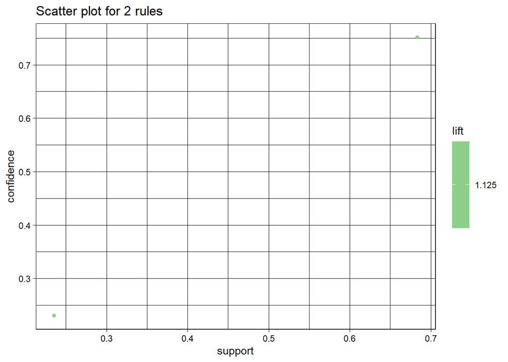

```r
plot(rules_diapers,control=list(jitter=2, col = rev(brewer.pal(9, "Greens")[4:9])),shading = "lift")
```

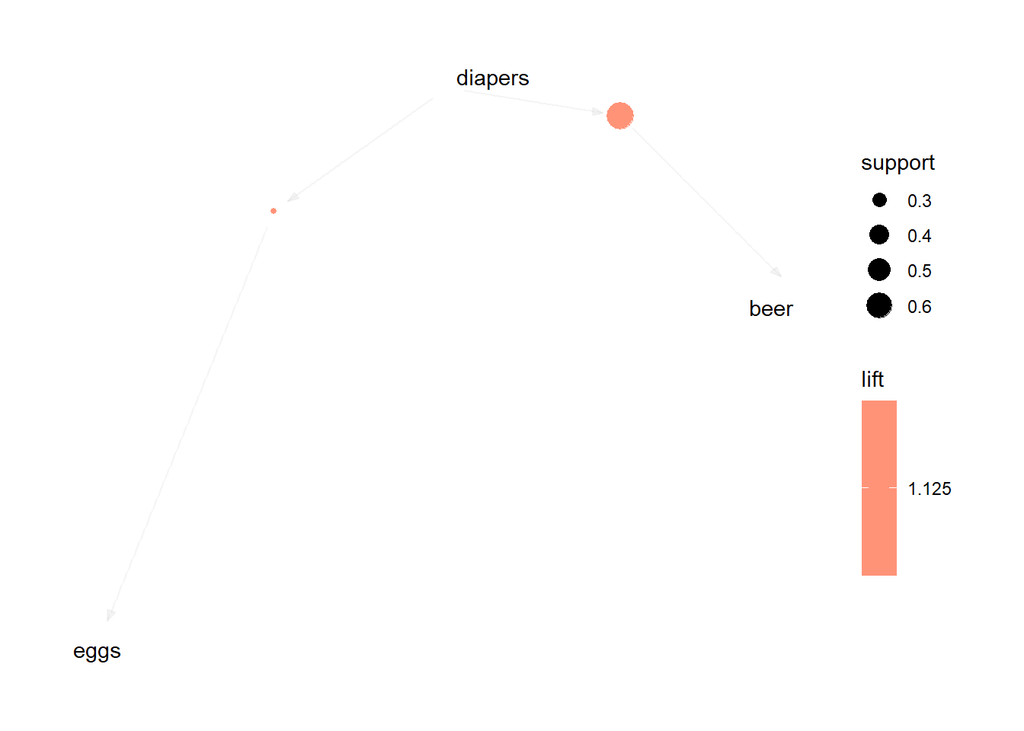

```r
plot(rules_diapers, method="graph", shading = "lift")
```

This file was generated using R Version 4.1.2